# 2.1_Describing_Univariate_Data

## DATA 201

## Describing Univariate Data with Statistics and Plots

Before building a model or doing any analysis, it's important to understand the data you are working with. This includes things such as understanding what was measured, how the data was collected, being able to produce useful summaries of the data, and determine if there are any potential problems/mistakes in the data.

Additionally, these things are also useful when you are trying to interpret the results of someone else's analysis.

You should ALWAYS, ALWAYS look at your data. Don't assume that any method you are trying to use automatically works for the type of data you have.

```python
#data source: Times Higher Education/Wall Street Journal via Kaggle:
#https://www.kaggle.com/datasets/mylesoneill/world-university-rankings
#methodology
```

```python
import pandas as pd
```

```python
college = pd.read_csv('./data/timesData.csv')
```

```python
college.tail(3)
```

|  | world_rank | university_name | country | teaching | international | research | citations | income | total_score | num_students | student_staff_ratio | international_students | female_male_ratio | year |
| --- | --- | --- | --- | --- | --- | --- | --- | --- | --- | --- | --- | --- | --- | --- |
| 2600 | 601-800 | Yokohama City University | Japan | 24.0 | 16.1 | 10.2 | 36.4 | 37.9 | - | 4,122 | 3.7 | 3% | NaN | 2016 |
| 2601 | 601-800 | Yokohama National University | Japan | 20.1 | 23.3 | 16.0 | 13.5 | 40.4 | - | 10,117 | 12.1 | 8% | 28 : 72 | 2016 |
| 2602 | 601-800 | Yuan Ze University | Taiwan | 16.2 | 17.7 | 18.3 | 28.6 | 39.8 | - | 8,663 | 20.6 | 4% | 43 : 57 | 2016 |

```python
college.set_index('university_name', inplace = True)
```

```python
college.head()
```

| university_name | world_rank | country | teaching | international | research | citations | income | total_score | num_students | student_staff_ratio | international_students | female_male_ratio | year |
| --- | --- | --- | --- | --- | --- | --- | --- | --- | --- | --- | --- | --- | --- |
| Harvard University | 1 | United States of America | 99.7 | 72.4 | 98.7 | 98.8 | 34.5 | 96.1 | 20,152 | 8.9 | 25% | NaN | 2011 |
| California Institute of Technology | 2 | United States of America | 97.7 | 54.6 | 98.0 | 99.9 | 83.7 | 96.0 | 2,243 | 6.9 | 27% | 33 : 67 | 2011 |
| Massachusetts Institute of Technology | 3 | United States of America | 97.8 | 82.3 | 91.4 | 99.9 | 87.5 | 95.6 | 11,074 | 9.0 | 33% | 37 : 63 | 2011 |
| Stanford University | 4 | United States of America | 98.3 | 29.5 | 98.1 | 99.2 | 64.3 | 94.3 | 15,596 | 7.8 | 22% | 42 : 58 | 2011 |
| Princeton University | 5 | United States of America | 90.9 | 70.3 | 95.4 | 99.9 | - | 94.2 | 7,929 | 8.4 | 27% | 45 : 55 | 2011 |

```python
college['country'].value_counts()
```

```
country
United States of America     659
United Kingdom               300
Germany                      152
Australia                    117
Canada                       108
                            ...
Unted Kingdom                  1
Cyprus                         1
Unisted States of America      1
Luxembourg                     1
Lithuania                      1
Name: count, Length: 72, dtype: int64
```

```python
#Find WM
wm = college.index.str.contains('Mary')
college[wm]
```

| university_name | world_rank | country | teaching | international | research | citations | income | total_score | num_students | student_staff_ratio | international_students | female_male_ratio | year |
| --- | --- | --- | --- | --- | --- | --- | --- | --- | --- | --- | --- | --- | --- |
| William & Mary | 75 | United States of America | 53.1 | 20.9 | 36.1 | 95.6 | - | 60.4 | 7,867 | 11.8 | 7% | 54 : 46 | 2011 |
| University of Maryland, College Park | 98 | United States of America | 45.4 | 35.4 | 48.6 | 79.2 | - | 57.2 | 31,331 | 8.4 | 9% | 48 : 52 | 2011 |
| Queen Mary University of London | 120 | United Kingdom | 39.7 | 91.0 | 44.1 | 73.5 | 38.9 | 54.6 | 14,260 | 14.0 | 40% | 52 : 48 | 2011 |
| University of Maryland, College Park | 94 | United States of America | 41.1 | 35.3 | 43.6 | 85.8 | 28.5 | 54.5 | 31,331 | 8.4 | 9% | 48 : 52 | 2012 |
| Queen Mary University of London | 127 | United Kingdom | 29.0 | 88.8 | 28.6 | 83.7 | 36.6 | 49.9 | 14,260 | 14.0 | 40% | 52 : 48 | 2012 |
| William & Mary | 146 | United States of America | 40.0 | 19.7 | 18.9 | 90.7 | 27.0 | 47.0 | 7,867 | 11.8 | 7% | 54 : 46 | 2012 |
| University of Maryland, Baltimore County | 301-350 | United States of America | 17.6 | 18.6 | 14.5 | 52.8 | 29.9 | - | 13,908 | 18.1 | 7% | 46 : 54 | 2012 |
| University of Maryland, College Park | 97 | United States of America | 44.9 | 40.4 | 51.4 | 83.9 | 32.1 | 57.9 | 31,331 | 8.4 | 9% | 48 : 52 | 2013 |
| Queen Mary University of London | 145 | United Kingdom | 33.1 | 87.0 | 30.0 | 85.4 | 42.7 | 52.1 | 14,260 | 14.0 | 40% | 52 : 48 | 2013 |
| William & Mary | 184 | United States of America | 41.3 | 25.8 | 22.6 | 87.1 | 29.9 | 48.0 | 7,867 | 11.8 | 7% | 54 : 46 | 2013 |
| University of Maryland, Baltimore County | 301-350 | United States of America | 19.4 | 32.6 | 16.4 | 65.2 | 32.6 | - | 13,908 | 18.1 | 7% | 46 : 54 | 2013 |
| University of Maryland, College Park | 108 | United States of America | 39.0 | 42.4 | 37.2 | 84.4 | 32.1 | 52.2 | 31,331 | 8.4 | 9% | 48 : 52 | 2014 |
| Queen Mary University of London | 114 | United Kingdom | 31.0 | 88.0 | 29.2 | 87.0 | 37.7 | 51.7 | 14,260 | 14.0 | 40% | 52 : 48 | 2014 |
| William & Mary | 201-225 | United States of America | 37.2 | 26.0 | 18.5 | 73.6 | 31.9 | - | 7,867 | 11.8 | 7% | 54 : 46 | 2014 |
| University of Maryland, Baltimore County | 351-400 | United States of America | 16.9 | 34.4 | 15.0 | 65.9 | 32.6 | - | 13,908 | 18.1 | 7% | 46 : 54 | 2014 |
| Queen Mary University of London | 107 | United Kingdom | 32.4 | 88.6 | 32.9 | 88.9 | 37.1 | 53.8 | 14,260 | 14.0 | 40% | 52 : 48 | 2015 |
| University of Maryland, College Park | 132 | United States of America | 36.5 | 44.8 | 39.1 | 83.6 | 33.2 | 51.9 | 31,331 | 8.4 | 9% | 48 : 52 | 2015 |
| William & Mary | 201-225 | United States of America | 36.8 | 26.5 | 19.9 | 78.7 | 30.0 | - | 7,867 | 11.8 | 7% | 54 : 46 | 2015 |
| Queen Mary University of London | 98 | United Kingdom | 34.1 | 93.5 | 41.3 | 93.3 | 36.8 | 58.5 | 14,260 | 14.0 | 40% | 52 : 48 | 2016 |
| University of Maryland, College Park | 117 | United States of America | 45.0 | 43.5 | 42.1 | 88.2 | 32.3 | 56.7 | 31,331 | 8.4 | 9% | 48 : 52 | 2016 |
| William & Mary | 201-250 | United States of America | 38.5 | 26.6 | 17.5 | 85.0 | 29.1 | - | 7,867 | 11.8 | 7% | 54 : 46 | 2016 |
| University of Maryland, Baltimore County | 401-500 | United States of America | 21.3 | 28.2 | 18.2 | 61.3 | 31.7 | - | 13,908 | 18.1 | 7% | 46 : 54 | 2016 |

```python
college.loc['William & Mary']
```

| university_name | world_rank | country | teaching | international | research | citations | income | total_score | num_students | student_staff_ratio | international_students | female_male_ratio | year |
| --- | --- | --- | --- | --- | --- | --- | --- | --- | --- | --- | --- | --- | --- |
| William & Mary | 75 | United States of America | 53.1 | 20.9 | 36.1 | 95.6 | - | 60.4 | 7,867 | 11.8 | 7% | 54 : 46 | 2011 |
| William & Mary | 146 | United States of America | 40.0 | 19.7 | 18.9 | 90.7 | 27.0 | 47.0 | 7,867 | 11.8 | 7% | 54 : 46 | 2012 |
| William & Mary | 184 | United States of America | 41.3 | 25.8 | 22.6 | 87.1 | 29.9 | 48.0 | 7,867 | 11.8 | 7% | 54 : 46 | 2013 |
| William & Mary | 201-225 | United States of America | 37.2 | 26.0 | 18.5 | 73.6 | 31.9 | - | 7,867 | 11.8 | 7% | 54 : 46 | 2014 |
| William & Mary | 201-225 | United States of America | 36.8 | 26.5 | 19.9 | 78.7 | 30.0 | - | 7,867 | 11.8 | 7% | 54 : 46 | 2015 |
| William & Mary | 201-250 | United States of America | 38.5 | 26.6 | 17.5 | 85.0 | 29.1 | - | 7,867 | 11.8 | 7% | 54 : 46 | 2016 |

```python
college.query('university_name=="William & Mary"')
```

| university_name | world_rank | country | teaching | international | research | citations | income | total_score | num_students | student_staff_ratio | international_students | female_male_ratio | year |
| --- | --- | --- | --- | --- | --- | --- | --- | --- | --- | --- | --- | --- | --- |
| William & Mary | 75 | United States of America | 53.1 | 20.9 | 36.1 | 95.6 | - | 60.4 | 7,867 | 11.8 | 7% | 54 : 46 | 2011 |
| William & Mary | 146 | United States of America | 40.0 | 19.7 | 18.9 | 90.7 | 27.0 | 47.0 | 7,867 | 11.8 | 7% | 54 : 46 | 2012 |
| William & Mary | 184 | United States of America | 41.3 | 25.8 | 22.6 | 87.1 | 29.9 | 48.0 | 7,867 | 11.8 | 7% | 54 : 46 | 2013 |
| William & Mary | 201-225 | United States of America | 37.2 | 26.0 | 18.5 | 73.6 | 31.9 | - | 7,867 | 11.8 | 7% | 54 : 46 | 2014 |
| William & Mary | 201-225 | United States of America | 36.8 | 26.5 | 19.9 | 78.7 | 30.0 | - | 7,867 | 11.8 | 7% | 54 : 46 | 2015 |
| William & Mary | 201-250 | United States of America | 38.5 | 26.6 | 17.5 | 85.0 | 29.1 | - | 7,867 | 11.8 | 7% | 54 : 46 | 2016 |

```python
#What types of variables do we have here?
#Does it make sense to find the average ranking for schools in a particular country?
#There are larger issues if you look at the methodology?
#Suppose we had zip/postal code...what type of variable would that be?
```

## Summary statistics

The most commonly used summary statistics tend to come in two broad categories:

1. Measures of central tendency: what is a "typical" observation? (mean, median, mode)
2. Measures of variability: how spread out is the data around the center? (stdev, IQR)

The interquartile range (IQR) is a measure of statistical dispersion, or the spread of the data, in descriptive statistics. Aka the middle 50%.

```python
import numpy as np
import matplotlib.pyplot as plt
```

### Measures of central tendency and histograms

```python
#Let's generate some fake data
# How many data points do I want?
n = 1000000

# Set the random seed to make sure we get the same answers
np.random.seed(146)
x1 = np.random.random(size=n)
```

```python
np.mean(x1)
```

```
0.5003746329139543
```

```python
np.median(x1)
```

```
0.5008503639428961
```

```python
#Let's generate more fake data
a = 0.1
b = 0.1
n = 1000000
np.random.seed(100)
x2 = np.random.beta(a,b,size=n)
```

```python
np.mean(x2)
```

```
0.49955765208281727
```

```python
np.median(x2)
```

```
0.49741088287963087
```

How similar are these two data sets actually? ALWAYS look at the data - don't make your decisions based on summary statistics alone.

A **histogram** is a good way to explore the distribution of our data. What do we mean by a distribution?

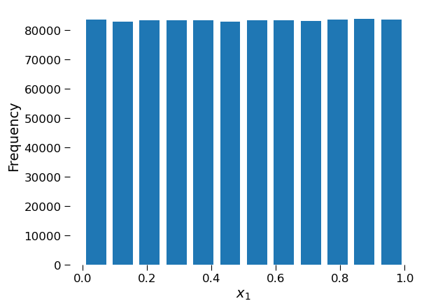

```python
plt.hist(x1, rwidth = 0.75, bins=12) #rwidth: relative width of the bars as a fraction of the bin width
ax = plt.gca() #get the current axis
[ax.spines[i].set_visible(False) for i in ax.spines] # An axis spine -- the line noting the data area boundaries.
plt.tick_params(labelsize = 12, size = 5.5)
plt.ylabel('Frequency', fontsize = 14)
plt.xlabel('$x_1$', fontsize = 14)
plt.show()
```

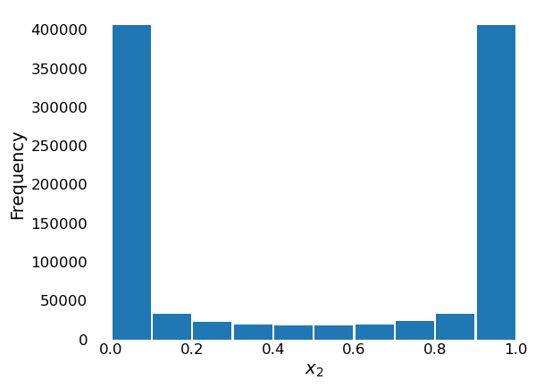

```python
plt.hist(x2, rwidth = 0.95)
ax = plt.gca()
[ax.spines[i].set_visible(False) for i in ax.spines]
plt.tick_params(labelsize = 12, size = 0)
plt.ylabel('Frequency', fontsize = 14)
plt.xlabel('$x_2$', fontsize = 14)
plt.show()
```

How would you describe each of these distributions?

Now let's look at the mean and median for the number of students in the college data for 2016.

```python
college_2016 = college[college['year'] == 2016]
```

```python
college_2016.head()
```

| university_name | world_rank | country | teaching | international | research | citations | income | total_score | num_students | student_staff_ratio | international_students | female_male_ratio | year |
| --- | --- | --- | --- | --- | --- | --- | --- | --- | --- | --- | --- | --- | --- |
| California Institute of Technology | 1 | United States of America | 95.6 | 64.0 | 97.6 | 99.8 | 97.8 | 95.2 | 2,243 | 6.9 | 27% | 33 : 67 | 2016 |
| University of Oxford | 2 | United Kingdom | 86.5 | 94.4 | 98.9 | 98.8 | 73.1 | 94.2 | 19,919 | 11.6 | 34% | 46 : 54 | 2016 |
| Stanford University | 3 | United States of America | 92.5 | 76.3 | 96.2 | 99.9 | 63.3 | 93.9 | 15,596 | 7.8 | 22% | 42 : 58 | 2016 |
| University of Cambridge | 4 | United Kingdom | 88.2 | 91.5 | 96.7 | 97.0 | 55.0 | 92.8 | 18,812 | 11.8 | 34% | 46 : 54 | 2016 |
| Massachusetts Institute of Technology | 5 | United States of America | 89.4 | 84.0 | 88.6 | 99.7 | 95.4 | 92.0 | 11,074 | 9.0 | 33% | 37 : 63 | 2016 |

```python
college_2016['num_students'].describe()
```

```
count        793
unique       791
top       23,321
freq           2
Name: num_students, dtype: object
```

```python
#Why is this happening????? Do you see the problem?
college_2016.dtypes
```

```
world_rank                 object
country                    object
teaching                  float64
international              object
research                  float64
citations                 float64
income                     object
total_score                object
num_students               object
student_staff_ratio       float64
international_students     object
female_male_ratio          object
year                        int64
dtype: object
```

```python
#Let's change this in the full data set and then subset again
students = college['num_students'].str.replace(',','').astype('float')
```

```python
college['num_students'] = students
```

```python
college.head(3)
```

| university_name | world_rank | country | teaching | international | research | citations | income | total_score | num_students | student_staff_ratio | international_students | female_male_ratio | year |
| --- | --- | --- | --- | --- | --- | --- | --- | --- | --- | --- | --- | --- | --- |
| Harvard University | 1 | United States of America | 99.7 | 72.4 | 98.7 | 98.8 | 34.5 | 96.1 | 20152.0 | 8.9 | 25% | NaN | 2011 |
| California Institute of Technology | 2 | United States of America | 97.7 | 54.6 | 98.0 | 99.9 | 83.7 | 96.0 | 2243.0 | 6.9 | 27% | 33 : 67 | 2011 |
| Massachusetts Institute of Technology | 3 | United States of America | 97.8 | 82.3 | 91.4 | 99.9 | 87.5 | 95.6 | 11074.0 | 9.0 | 33% | 37 : 63 | 2011 |

```python
college_2016 = college[college['year'] == 2016]
```

```python
college_2016.dtypes
```

```
world_rank                 object
country                    object
teaching                  float64
international              object
research                  float64
citations                 float64
income                     object
total_score                object
num_students              float64
student_staff_ratio       float64
international_students     object
female_male_ratio          object
year                        int64
dtype: object
```

```python
college_2016['num_students'].mean()
```

```
24161.264817150062
```

```python
college_2016['num_students'].median()
```

```
20174.0
```

Based on the values of the mean and the median, do we expect the histogram to be symmetric? Skewed left? Skewed right?

```python
college_2016['num_students'].isnull()
```

```
university_name
California Institute of Technology       False
University of Oxford                     False
Stanford University                      False
University of Cambridge                  False
Massachusetts Institute of Technology    False
                                         ...
Yeungnam University                      False
Yıldız Technical University              False
Yokohama City University                 False
Yokohama National University             False
Yuan Ze University                       False
Name: num_students, Length: 800, dtype: bool
```

```python
college_2016['num_students'].isnull().value_counts()
```

```
num_students
False    793
True       7
Name: count, dtype: int64
```

```python
college_2016['num_students'].describe()
```

```
count       793.000000
mean      24161.264817
std       22569.224842
min         462.000000
25%       12331.000000
50%       20174.000000
75%       29700.000000
max      379231.000000
Name: num_students, dtype: float64
```

```python
college_2016['num_students'].info()
```

```
<class 'pandas.core.series.Series'>
Index: 800 entries, California Institute of Technology to Yuan Ze University
Series name: num_students
Non-Null Count  Dtype
--------------  -----
793 non-null    float64
dtypes: float64(1)
memory usage: 44.8+ KB
```

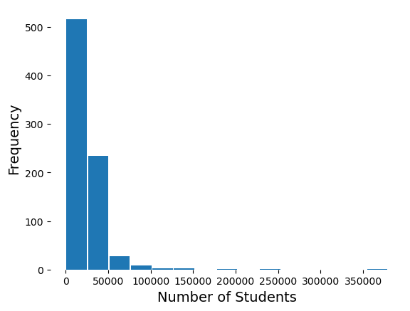

```python
#What happens to missing values?
#We might want to mod the bin size here
n_bins = 15
min_val = college_2016['num_students'].min()
max_val = college_2016['num_students'].max()
bins = np.linspace(min_val, max_val, n_bins+1)
#notice we are making the plot differently here
#using a Series method


ax = college_2016['num_students'].hist(rwidth = 0.95, bins = bins)
[ax.spines[i].set_visible(False) for i in ax.spines]
plt.ylabel('Frequency', fontsize = 14)
plt.xlabel('Number of Students', fontsize = 14)
plt.grid(None)
plt.show()
```

Whenever you see something like this, where there are a few really large values, and the rest are much smaller, using a **logarithmic** transformation can be useful. When looking at the log of a number, you are essentially shifting your focus from the actual value of the number to how many digits it has.

For example: $$ 123,456,789 \approx 1.2 \times 10^8 $$

```python
n_bins = 10
min_val = np.log10(college_2016['num_students']).min()
max_val = np.log10(college_2016['num_students']).max()
bins = np.linspace(1, max_val, n_bins+1)
#notice we are making the plot differently here
#using a Series method
"""
ax = np.log10(college_2016['num_students']).hist(rwidth = 0.95, bins = bins)
[ax.spines[i].set_visible(False) for i in ax.spines]
plt.ylabel('Frequency', fontsize = 14)
plt.xlabel('$log_{10}$'+' Number of Students', fontsize = 14)
plt.grid(None)
plt.show()
"""
print(bins)
```

```
[1.         1.45789038 1.91578077 2.37367115 2.83156153 3.28945192
 3.7473423  4.20523268 4.66312306 5.12101345 5.57890383]
```

### Measures of variation (spread)

Next, we'll look at some **measures of variation**. While the goal of means and medians is to give a sense of the "middle" of the data, measures of variation tell us how far away from the middle the data tends to be.

The most common measure is the variance, which is the average of the squared differences between each data point and the mean. Mathematically, if $X=\{x_1,x_2,...,x_N\}$ is a set of $N$ observations, then:

$$Var[X] = \frac{1}{N}\sum_{i=1}^N (x_i-\mu)^2$$

where $\mu$ is the mean. You will also often see the symbol $\sigma^2$ used to denote the variance.

```python
np.var(college_2016['num_students'])
#college_2016['num_students'].var()
```

```
508727577.1606413
```

```python
college_2016.info()
```

```
<class 'pandas.core.frame.DataFrame'>
Index: 800 entries, California Institute of Technology to Yuan Ze University
Data columns (total 13 columns):
 #   Column                  Non-Null Count  Dtype
---  ------                  --------------  -----
 0   world_rank              800 non-null    object
 1   country                 800 non-null    object
 2   teaching                800 non-null    float64
 3   international           800 non-null    object
 4   research                800 non-null    float64
 5   citations               800 non-null    float64
 6   income                  800 non-null    object
 7   total_score             800 non-null    object
 8   num_students            793 non-null    float64
 9   student_staff_ratio     793 non-null    float64
 10  international_students  790 non-null    object
 11  female_male_ratio       739 non-null    object
 12  year                    800 non-null    int64
dtypes: float64(5), int64(1), object(7)
memory usage: 119.8+ KB
```

```python
fil_college_2016 = college_2016[college_2016['num_students'].isnull()==False]
```

```python
fil_college_2016.info()
```

```
<class 'pandas.core.frame.DataFrame'>
Index: 793 entries, California Institute of Technology to Yuan Ze University
Data columns (total 13 columns):
 #   Column                  Non-Null Count  Dtype
---  ------                  --------------  -----
 0   world_rank              793 non-null    object
 1   country                 793 non-null    object
 2   teaching                793 non-null    float64
 3   international           793 non-null    object
 4   research                793 non-null    float64
 5   citations               793 non-null    float64
 6   income                  793 non-null    object
 7   total_score             793 non-null    object
 8   num_students            793 non-null    float64
 9   student_staff_ratio     793 non-null    float64
 10  international_students  790 non-null    object
 11  female_male_ratio       739 non-null    object
 12  year                    793 non-null    int64
dtypes: float64(5), int64(1), object(7)
memory usage: 86.7+ KB
```

```python
np.var(college_2016['num_students'])
```

```
508727577.1606413
```

```python
np.var(fil_college_2016['num_students'])
```

```
508727577.1606413
```

```python
college_2016['num_students'].var()
```

```
509369909.9600865
```

```python
fil_college_2016['num_students'].var()
```

```
509369909.9600865
```

```python
fil_college_2016['num_students'].var()*(len(fil_college_2016['num_students'])-1)/len(fil_college_2016['num_students'])
```

```
508727577.1606413
```

```python
college_2016['num_students'].var()*(len(college_2016['num_students'])-1)/len(college_2016['num_students'])
```

```
508733197.5726364
```

```python
# (referred to the above) why is that?
```

It is common for people to look at the **standard deviation**, which is just the square root of the variance (and is often denoted as $\sigma$). The benefit of this is that the standard deviation and the mean have the same physical units, so they are more directly comparable. Note that the variance and standard deviation "pair with" the mean - they are the appropriate measures of variation to report when you report the mean.

```python
np.std(college_2016['num_students'])
```

```
22554.990072279823
```

Taking the ratio of standard deviation / mean is called the **coefficient of variation**.

```python
np.std(college_2016['num_students'])/np.mean(college_2016['num_students'])
```

```
0.9335185985904977
```

### Quartiles and Box Plots

Quartiles are computed by sorting the data and splitting it into 4 equally sized groups (hence "quart-", meaning 4). The numbers reported are the values which split each of these groups (see this [wikipedia page](https://en.wikipedia.org/wiki/Quantile) for some example computations). In other words, the quartiles of a data set are the 25th, 50th, and 75th percentiles, since those three values divide the data into 4 equally sized groups.

Let's compute the quartiles of the number of students in 2016:

```python
q = np.quantile(college_2016['num_students'].values, [0.25, 0.5, 0.75])
```

```python
print(q)
```

```
[nan nan nan]
```

```python
college_2016['num_students'].describe()
```

```
count       793.000000
mean      24161.264817
std       22569.224842
min         462.000000
25%       12331.000000
50%       20174.000000
75%       29700.000000
max      379231.000000
Name: num_students, dtype: float64
```

```python
#What is going on????
college_2016['num_students'].isnull().sum()
```

```
7
```

```python
students = college_2016['num_students'].dropna()
```

```python
students
```

```
university_name
California Institute of Technology        2243.0
University of Oxford                     19919.0
Stanford University                      15596.0
University of Cambridge                  18812.0
Massachusetts Institute of Technology    11074.0
                                          ...
Yeungnam University                      21958.0
Yıldız Technical University              31268.0
Yokohama City University                  4122.0
Yokohama National University             10117.0
Yuan Ze University                        8663.0
Name: num_students, Length: 793, dtype: float64
```

```python
q = np.quantile(students, [0.25, 0.5, 0.75])
```

```python
print(q)
#What does the second number in this list correspond to?
```

```
[12331. 20174. 29700.]
```

Let's look at the citations:

```python
q = np.quantile(college_2016['citations'].dropna(), [0.25, 0.5, 0.75, 0.93])
```

```python
q
```

```
array([27.525, 50.3  , 74.9  , 91.507])
```

Let's make boxplots of both variables:

What does this box plot tell you about the data?

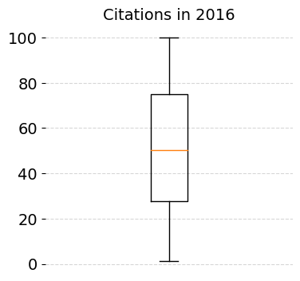

```python
plt.figure(figsize=(4,4))
plt.boxplot(college_2016['citations'].dropna())
ax = plt.gca()
[ax.spines[i].set_visible(False) for i in ax.spines]
plt.xticks([])
plt.yticks(fontsize = 14)
plt.grid(linestyle = '--', alpha = 0.5)
plt.title('Citations in 2016', fontsize=14)
plt.show()
```

```python
college_2016['num_students'].tail()
```

```
university_name
Yeungnam University             21958.0
Yıldız Technical University     31268.0
Yokohama City University         4122.0
Yokohama National University    10117.0
Yuan Ze University               8663.0
Name: num_students, dtype: float64
```

How about this one?

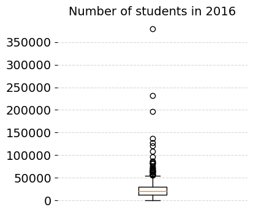

```python
plt.figure(figsize=(4,4))
plt.boxplot(college_2016['num_students'].dropna())
ax = plt.gca()
[ax.spines[i].set_visible(False) for i in ax.spines]
plt.xticks([])
plt.yticks(fontsize = 14)
plt.grid(linestyle = '--', alpha = 0.5)
plt.title('Number of students in 2016', fontsize=14)
plt.show()
```

## Looking at distributions over a category

```python
idx_canada = college['country'] == 'Canada'
college_ca = college[idx_canada]
```

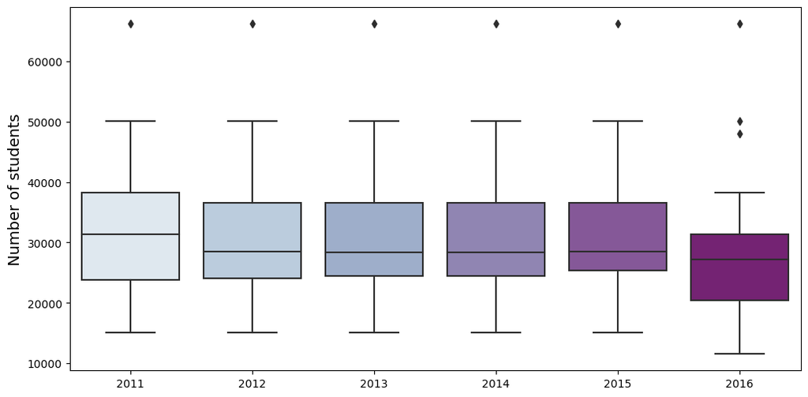

```python
import seaborn as sns
plt.figure(figsize=(12,6))
sns.boxplot(x='year', y='num_students', data = college_ca, palette = 'BuPu') #palette = 'BuPu'
plt.ylabel('Number of students', fontsize=14)
plt.xlabel('')
plt.show()

# https://medium.com/analytics-vidhya/deep-dive-into-seaborn-palettes-7b5fae5a258e
```

A stripchart is a VERY useful plot to show the spread of your data and also how many data points there are. Here is a stripchart of the same data:

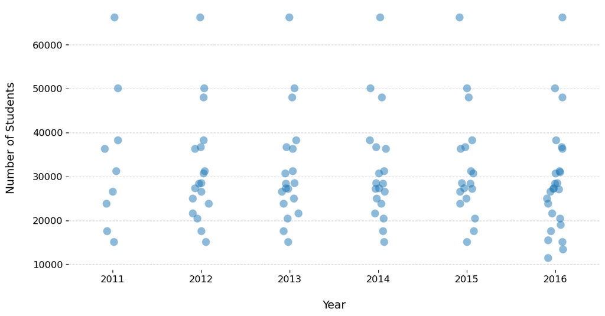

```python
plt.figure(figsize = [12,6])
ax = plt.gca()
[ax.spines[i].set_visible(False) for i in ax.spines]
sns.stripplot(x = 'year', y = 'num_students', data = college_ca, size = 10, alpha = 0.5,
             jitter = True)
plt.ylabel('Number of Students', labelpad = 20, fontsize = 14)
plt.xlabel('Year', labelpad = 20, fontsize = 14)
plt.tick_params(labelsize = 12)
plt.grid(axis = 'y', linestyle = '--', alpha = 0.5)
plt.show()
```

How does this change the conclusions we might draw from the boxplot?